# biscuit_fire

ddxbugs

2024-02-08

##### Import data set

```r
library(dplyr)
loggingDF <- read.csv("Logging.csv", header=TRUE)
loggingDF
```

```
##    Action PercentLost
## 1       L        45.0
## 2       L        53.1
## 3       L        40.8
## 4       L        75.5
## 5       L        46.7
## 6       L        85.4
## 7       L        85.6
## 8       L        18.2
## 9       L        43.2
## 10      U        23.6
## 11      U        13.3
## 12      U        34.2
## 13      U        18.1
## 14      U        56.1
## 15      U        -8.1
## 16      U       -20.1
```

##### Tidy & Transform data set

```r
loggingDF %>% group_by(Action) %>% summarize(
  count <- n(),
  median <- median(PercentLost, na.rm=TRUE),
  IQR <- IQR(PercentLost, na.rm=TRUE)
)
```

```
## # A tibble: 2 × 4
##   Action `count <- n()` median <- median(PercentLost, n…¹ IQR <- IQR(PercentLo…²
##   <chr>           <int>                             <dbl>                  <dbl>
## 1 L                   9                              46.7                   32.3
## 2 U                   7                              18.1                   26.3
## # ℹ abbreviated names: ¹`median <- median(PercentLost, na.rm = TRUE)`,
## #   ²`IQR <- IQR(PercentLost, na.rm = TRUE)`
```

```r
actionU <- loggingDF %>% filter(Action == "U")
actionL <- loggingDF %>% filter(Action == "L")
```

##### Hypothesis Testing

###### H<sub>0</sub>: median(logged) = median(unlogged)

###### H<sub>A</sub>: median(logged) $\neq$ median(unlogged)

```r
# Determine critical value
qt(0.05, 10000)
```

```
## [1] -1.645006
```

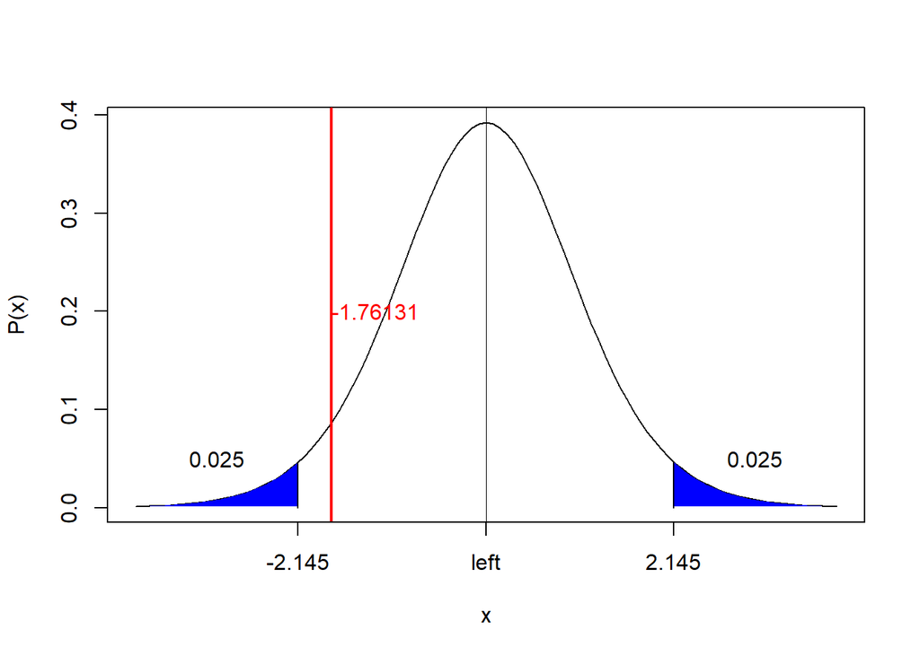

```r
#' Credit: Volodymyr Orlov
#' modified by MSDS SMU
#' https://github.com/VolodymyrOrlov/MSDS6371/blob/master/shade.r
#' Draws a t-distribution curve and shades rejection regions
#'
#' @param df degrees of freedom.
#' @param alpha significance level
#' @param h0 null hypothesis value
#' @param sides one of: both, left, right
#' @param t_calc calculated test statistics
#' @examples
#' shade(49, 0.05, 0, t_calc=1.1)
#' shade(91, 0.05, 0, t_calc=NULL, sides = 'right')
#' shade(7, 0.05, 0, t_calc=1.5, sides = 'left')
#' shade(7, 0.05, 0, t_calc=1.5, sides = 'both')

shade <- function(df, alpha, h0 = 0, sides='both', t_calc=NULL) {
  e_alpha = alpha
  if(sides == 'both'){
    e_alpha = alpha / 2
  }
  cv = abs(qt(e_alpha, df))
  curve(dt(x, df), from = -4, to = 4, ylab='P(x)', xaxt='n')
  abline(v = 0, col = "black", lwd = 0.5)
  labels = h0
  at = 0
  if(sides == 'both' | sides == 'left'){
    x <- seq(-4, -abs(cv), len = 100)
    y <- dt(x, df)
    polygon(c(x, -abs(cv)), c(y, min(y)), col = "blue", border = NA)
    lines(c(-cv, -cv), c(0, dt(-cv, df)), col = "black", lwd = 1)
    text(-cv - (4 - cv) / 2, 0.05, e_alpha)
    labels = c(round(-cv, 3), labels)
    at = c(-cv, at)
  }
  if(sides == 'both' | sides == 'right'){
    x <- seq(abs(cv), 4, len = 100)
    y <- dt(x, df)
    polygon(c(abs(cv), x), c(min(y), y), col = "blue", border = NA)
    lines(c(cv, cv), c(0, dt(cv, df)), col = "black", lwd = 1)
    text(cv + (4 - cv) / 2, 0.05, e_alpha)
    labels = c(labels, round(cv, 3))
    at = c(at, cv)
  }
  if(is.numeric(t_calc)){
    abline(v = t_calc, col = "red", lwd = 2)
    text(t_calc + 0.5, 0.2, t_calc, col = "red")
  }
  axis(1, at=at, labels=labels)
}
#The above defines the function shade. To use it, you must call it. More examples are in the comments above.
shade(14, 0.05, 'left', t_calc=-1.76131)
```

##### Wilcoxon Rank Sum Test

```r
wilcox.test(actionU$PercentLost, actionL$PercentLost, exact=TRUE)
```

```
##
##  Wilcoxon rank sum exact test
##
## data:  actionU$PercentLost and actionL$PercentLost
## W = 8, p-value = 0.01154
## alternative hypothesis: true location shift is not equal to 0
```

```r
wilcox.test(actionU$PercentLost, actionL$PercentLost, exact=TRUE, alternative="l")
```

```
##
##  Wilcoxon rank sum exact test
##
## data:  actionU$PercentLost and actionL$PercentLost
## W = 8, p-value = 0.005769
## alternative hypothesis: true location shift is less than 0
```

```r
wilcox.test(actionU$PercentLost, actionL$PercentLost, exact=FALSE, alternative="g")
```

```
##
##  Wilcoxon rank sum test with continuity correction
##
## data:  actionU$PercentLost and actionL$PercentLost
## W = 8, p-value = 0.9945
## alternative hypothesis: true location shift is greater than 0
```

##### Permutation Test

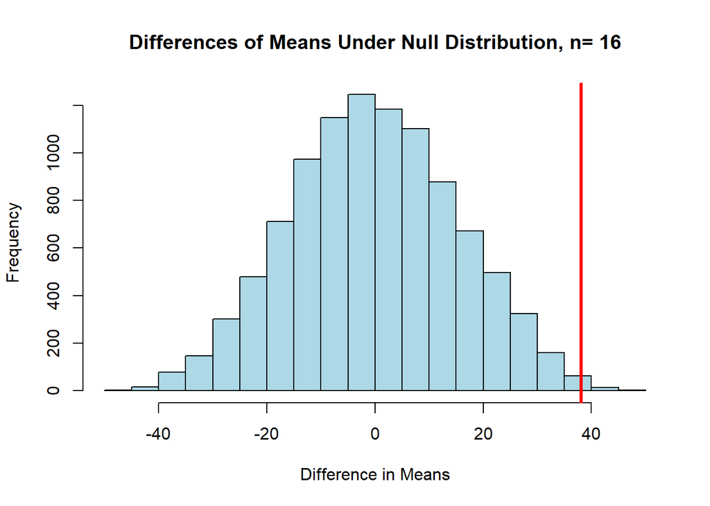

```r
number_of_permutations <- 10000
xbarholder <- c()
counter <- 0
observed_difference <- mean(subset(loggingDF, Action=="L")$PercentLost) - mean(subset(loggingDF, Action=="U")$PercentLost)
for (i in 1:number_of_permutations) {
  scramble <- sample(loggingDF$PercentLost, 16)
  logged <- scramble[1:9]
  unlogged <- scramble[10:16]
  difference <- mean(logged) - mean(unlogged)
  xbarholder[i] <- difference
  if (difference >= observed_difference)
    counter <- counter + 1
}
hist(xbarholder, col="lightblue", main=paste("Differences of Means Under Null Distribution, n=", 16), xlab="Difference in Means")
abline(v=observed_difference, col="red", lwd=3)
```

```r
p_value <- counter/number_of_permutations
p_value
```

```
## [1] 0.0032
```